# Model Selection and Assessment - Case

## Problem

Sweeper is a non-profit organization looking to defuse old, war-era underwater mines that pose a danger to the public. However, it is very difficult to tell the difference between mines and rocks underwater. They would like to know if they can predict the two based off of sonar data and have asked you to develop the model.

They note the following business constraints:

- Everything classified as a rock needs to be scanned at \$150/scan
- Everything classified as a mine needs to be defused at \$2000 if it is a real mine
- Everything classified as a mine needs to be defused at \$200 if it turns out to be a rock

In this case, you will learn:

- How to select and assess models
- How to turn a regression model into a classification model
- How to interpret ROC curves
- How to interpret Precision-Recall curves
- What it means to design a model under a business setting

## Step 1: Import Modules

```python
import pandas as pd
import numpy as np
import matplotlib.pyplot as plt
from sklearn.model_selection import cross_validate
from sklearn.metrics import accuracy_score
from sklearn.preprocessing import LabelEncoder
from sklearn.datasets import make_classification
from sklearn.model_selection import KFold
from sklearn.model_selection import train_test_split
from sklearn import linear_model
from sklearn.metrics import roc_curve, auc
from sklearn.metrics import precision_recall_curve
from sklearn.metrics import average_precision_score
from sklearn.metrics import confusion_matrix
%matplotlib inline
```

## Step 2: Read in Data

```python
url="http://archive.ics.uci.edu/ml/machine-learning-databases/undocumented/connectionist-bench/sonar/sonar.all-data"
df = pd.read_csv(url,header=None)
df.head()
```

|  | 0 | 1 | 2 | 3 | 4 | 5 | 6 | 7 | 8 | 9 | ... | 51 | 52 | 53 | 54 | 55 | 56 | 57 | 58 | 59 | 60 |
| --- | --- | --- | --- | --- | --- | --- | --- | --- | --- | --- | --- | --- | --- | --- | --- | --- | --- | --- | --- | --- | --- |
| 0 | 0.0200 | 0.0371 | 0.0428 | 0.0207 | 0.0954 | 0.0986 | 0.1539 | 0.1601 | 0.3109 | 0.2111 | ... | 0.0027 | 0.0065 | 0.0159 | 0.0072 | 0.0167 | 0.0180 | 0.0084 | 0.0090 | 0.0032 | R |
| 1 | 0.0453 | 0.0523 | 0.0843 | 0.0689 | 0.1183 | 0.2583 | 0.2156 | 0.3481 | 0.3337 | 0.2872 | ... | 0.0084 | 0.0089 | 0.0048 | 0.0094 | 0.0191 | 0.0140 | 0.0049 | 0.0052 | 0.0044 | R |
| 2 | 0.0262 | 0.0582 | 0.1099 | 0.1083 | 0.0974 | 0.2280 | 0.2431 | 0.3771 | 0.5598 | 0.6194 | ... | 0.0232 | 0.0166 | 0.0095 | 0.0180 | 0.0244 | 0.0316 | 0.0164 | 0.0095 | 0.0078 | R |
| 3 | 0.0100 | 0.0171 | 0.0623 | 0.0205 | 0.0205 | 0.0368 | 0.1098 | 0.1276 | 0.0598 | 0.1264 | ... | 0.0121 | 0.0036 | 0.0150 | 0.0085 | 0.0073 | 0.0050 | 0.0044 | 0.0040 | 0.0117 | R |
| 4 | 0.0762 | 0.0666 | 0.0481 | 0.0394 | 0.0590 | 0.0649 | 0.1209 | 0.2467 | 0.3564 | 0.4459 | ... | 0.0031 | 0.0054 | 0.0105 | 0.0110 | 0.0015 | 0.0072 | 0.0048 | 0.0107 | 0.0094 | R |

5 rows × 61 columns

The last column contains the Rock (R) and Mine (M) classifications.

## Step 3: Split Up Features and Dependent Variable

```python
X = df[df.columns[0:60]].values # select first 60 columns for features
y = df[df.columns[60]].values # select last column for dependent variable
y
```

```
array(['R', 'R', 'R', 'R', 'R', 'R', 'R', 'R', 'R', 'R', 'R', 'R', 'R',
       'R', 'R', 'R', 'R', 'R', 'R', 'R', 'R', 'R', 'R', 'R', 'R', 'R',
       'R', 'R', 'R', 'R', 'R', 'R', 'R', 'R', 'R', 'R', 'R', 'R', 'R',
       'R', 'R', 'R', 'R', 'R', 'R', 'R', 'R', 'R', 'R', 'R', 'R', 'R',
       'R', 'R', 'R', 'R', 'R', 'R', 'R', 'R', 'R', 'R', 'R', 'R', 'R',
       'R', 'R', 'R', 'R', 'R', 'R', 'R', 'R', 'R', 'R', 'R', 'R', 'R',
       'R', 'R', 'R', 'R', 'R', 'R', 'R', 'R', 'R', 'R', 'R', 'R', 'R',
       'R', 'R', 'R', 'R', 'R', 'R', 'M', 'M', 'M', 'M', 'M', 'M', 'M',
       'M', 'M', 'M', 'M', 'M', 'M', 'M', 'M', 'M', 'M', 'M', 'M', 'M',
       'M', 'M', 'M', 'M', 'M', 'M', 'M', 'M', 'M', 'M', 'M', 'M', 'M',
       'M', 'M', 'M', 'M', 'M', 'M', 'M', 'M', 'M', 'M', 'M', 'M', 'M',
       'M', 'M', 'M', 'M', 'M', 'M', 'M', 'M', 'M', 'M', 'M', 'M', 'M',
       'M', 'M', 'M', 'M', 'M', 'M', 'M', 'M', 'M', 'M', 'M', 'M', 'M',
       'M', 'M', 'M', 'M', 'M', 'M', 'M', 'M', 'M', 'M', 'M', 'M', 'M',
       'M', 'M', 'M', 'M', 'M', 'M', 'M', 'M', 'M', 'M', 'M', 'M', 'M',
       'M', 'M', 'M', 'M', 'M', 'M', 'M', 'M', 'M', 'M', 'M', 'M', 'M'], dtype=object)
```

```python
df[60].value_counts() # check class balance
```

```
M    111
R     97
Name: 60, dtype: int64
```

The classes are relatively well-balanced!

```python
X # check what features look like
```

```
array([[ 0.02  ,  0.0371,  0.0428, ...,  0.0084,  0.009 ,  0.0032],
       [ 0.0453,  0.0523,  0.0843, ...,  0.0049,  0.0052,  0.0044],
       [ 0.0262,  0.0582,  0.1099, ...,  0.0164,  0.0095,  0.0078],
       ...,
       [ 0.0522,  0.0437,  0.018 , ...,  0.0138,  0.0077,  0.0031],
       [ 0.0303,  0.0353,  0.049 , ...,  0.0079,  0.0036,  0.0048],
       [ 0.026 ,  0.0363,  0.0136, ...,  0.0036,  0.0061,  0.0115]])
```

## Step 4: Encode the Dependent Variables

```python
encoder = LabelEncoder()
encoder.fit(y)
y = encoder.transform(y) # labels R and M classes numerically
y
```

```
array([1, 1, 1, 1, 1, 1, 1, 1, 1, 1, 1, 1, 1, 1, 1, 1, 1, 1, 1, 1, 1, 1, 1,
       1, 1, 1, 1, 1, 1, 1, 1, 1, 1, 1, 1, 1, 1, 1, 1, 1, 1, 1, 1, 1, 1, 1,
       1, 1, 1, 1, 1, 1, 1, 1, 1, 1, 1, 1, 1, 1, 1, 1, 1, 1, 1, 1, 1, 1, 1,
       1, 1, 1, 1, 1, 1, 1, 1, 1, 1, 1, 1, 1, 1, 1, 1, 1, 1, 1, 1, 1, 1, 1,
       1, 1, 1, 1, 1, 0, 0, 0, 0, 0, 0, 0, 0, 0, 0, 0, 0, 0, 0, 0, 0, 0, 0,
       0, 0, 0, 0, 0, 0, 0, 0, 0, 0, 0, 0, 0, 0, 0, 0, 0, 0, 0, 0, 0, 0, 0,
       0, 0, 0, 0, 0, 0, 0, 0, 0, 0, 0, 0, 0, 0, 0, 0, 0, 0, 0, 0, 0, 0, 0,
       0, 0, 0, 0, 0, 0, 0, 0, 0, 0, 0, 0, 0, 0, 0, 0, 0, 0, 0, 0, 0, 0, 0,
       0, 0, 0, 0, 0, 0, 0, 0, 0, 0, 0, 0, 0, 0, 0, 0, 0, 0, 0, 0, 0, 0, 0,
       0])
```

## Step 5: Train-Test - Linear Regression

```python
X_train, X_test, y_train, y_test = train_test_split(X, y, test_size = 0.25, random_state = 1) # get training and test sets
```

```python
model = linear_model.LinearRegression() # create linear regression model
model.fit(X_train,y_train) # fit results onto linear regression
```

```
LinearRegression(copy_X=True, fit_intercept=True, n_jobs=None, normalize=False)
```

```python
y_pred  = model.predict(X_test) # get predictions on test data
y_pred # see what predictions look like
```

```
array([ 0.09354297,  0.82719804,  0.7230885 , -0.17524652,  0.84381952,
        0.06104215,  0.71869062,  1.25545847,  0.32940821,  0.82762727,
       -0.10189742,  0.12216419,  0.22694054,  0.46646631,  0.5354342 ,
        0.25895493,  0.90042994,  0.06109083,  0.19832473,  0.97575141,
       -0.07696108,  0.95709474,  0.40854048,  0.69036019,  0.12406364,
       -0.02697221,  0.93351602,  0.44687593,  1.26421731,  0.12333641,
        0.66241672, -0.00370672,  0.58170727,  1.22690323,  0.50736027,
        0.63007647,  0.79162502, -0.05278872,  0.92755657,  0.0077093 ,
        0.24704382,  0.53098845,  0.20917705,  0.53051021,  0.43098779,
       -0.3484584 ,  0.95706732,  1.34030462,  0.37328061,  0.34671065,
        0.26615979, -0.08865223])
```

Notice that the above results are not in terms of 0 and 1.

To turn this into a classification problem, we can introduce a threshold $\tau$ where if a prediction is above $\tau$ we classify it as 1, else 0.

## Step 6: Make Classification Threshold Function

```python
def get_classification(predictions,threshold): # converts predictions into class predictions
    classes = np.zeros_like(predictions) # create array of zeros with same dimensions as predictions
    for i in range(len(classes)):
    # for each element in classes, convert to a 1 if the prediction is greater than the threshold
        if predictions[i] > threshold:
            classes[i] = 1
    return classes
```

```python
get_classification(y_pred,0.5) # example
```

```
array([ 0.,  1.,  1.,  0.,  1.,  0.,  1.,  1.,  0.,  1.,  0.,  0.,  0.,
        0.,  1.,  0.,  1.,  0.,  0.,  1.,  0.,  1.,  0.,  1.,  0.,  0.,
        1.,  0.,  1.,  0.,  1.,  0.,  1.,  1.,  1.,  1.,  1.,  0.,  1.,
        0.,  0.,  1.,  0.,  1.,  0.,  0.,  1.,  1.,  0.,  0.,  0.,  0.])
```

For this, we are using a threshold of 0.5 as we want to evenly classify rocks and mines.

## Step 7: Evaluate Accuracy

```python
acc = accuracy_score(y_true=y_test, y_pred=get_classification(y_pred,0.5)) # get accuracy
acc
```

```
0.71153846153846156
```

## Step 8: 5-Fold Cross Validation

We can get a better understanding on the model's performance with a 5-fold cross-validation.

```python
kfold = KFold(n_splits = 5, shuffle = True, random_state = 1) # split into 5 folds
X_train, X_test, y_train, y_test = train_test_split(X, y, test_size=0.25, random_state=42) # get training and test data

acc_list = []
for train_ix, test_ix in kfold.split(X_train): # for each train and test fold
    X_train_k, X_test_k = X_train[train_ix], X_train[test_ix] # split training dataset into training fold and test fold
    y_train_k, y_test_k = y_train[train_ix], y_train[test_ix]
    model = linear_model.LinearRegression() # create linear regression model
    model.fit(X_train_k,y_train_k) # fit model on training fold
    y_pred = model.predict(X_test_k) # get predictions from test fold
    acc = accuracy_score(y_true=y_test_k, y_pred=get_classification(y_pred,0.5)) # get accuracy
    acc_list.append(acc) # add accuracy to list
print('Accuracy of each fold:')
print(acc_list) # accuracy of each fold
print('Avg Accuracy of Model:')
print(np.mean(acc_list)) # get mean of accuracy
```

```
Accuracy of each fold:
[0.6875, 0.77419354838709675, 0.58064516129032262, 0.70967741935483875, 0.70967741935483875]
Avg Accuracy of Model:
0.692338709677
```

## Step 9: Compare to Logistic Regression

Let's try another model and also perform 5-fold cross validation to see which model performs better.

```python
kfold = KFold(n_splits = 5, shuffle = True, random_state = 1) # same process as linear regression but for logistic
X_train, X_test, y_train, y_test = train_test_split(X, y, test_size=0.25, random_state=42)

acc_list = []
for train_ix, test_ix in kfold.split(X_train):
    X_train_k, X_test_k = X_train[train_ix], X_train[test_ix]
    y_train_k, y_test_k = y_train[train_ix], y_train[test_ix]
    model = linear_model.LogisticRegression()
    model.fit(X_train_k,y_train_k)
    y_pred = model.predict_proba(X_test_k)[:,1] # to get probabilities of y = 1
    acc = accuracy_score(y_true=y_test_k, y_pred=get_classification(y_pred,0.5))
    acc_list.append(acc)
print('Accuracy of each fold:')
print(acc_list)
print('Avg Accuracy of Model:')
print(np.mean(acc_list))
```

```
Accuracy of each fold:
[0.6875, 0.77419354838709675, 0.54838709677419351, 0.77419354838709675, 0.77419354838709675]
Avg Accuracy of Model:
0.711693548387
```

**Analyze Results**

- The performance of the logistic regression was better than the linear regression, so let's use the logistic regression!
- For classification problems, we can use accuracy as our out-of-sample performance measure

## Step 10: Assess Logistic Regression Model

We can now train the selected model on all of the training data and test on the original test data.

```python
X_train, X_test, y_train, y_test = train_test_split(X, y, test_size=0.25, random_state=42)
model = linear_model.LogisticRegression()
model.fit(X_train,y_train)
y_pred = model.predict_proba(X_test)[:,1] # to get probabilities of y = 1
acc = accuracy_score(y_true=y_test, y_pred=get_classification(y_pred,0.5))
acc
```

```
0.80769230769230771
```

## Step 11: Plot ROC Curve

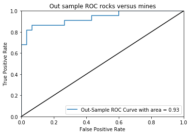

```python
(fpr, tpr, thresholds) = roc_curve(y_test,y_pred)

area = auc(fpr,tpr) # get area under curve
plt.clf() #Clear the current figure
plt.plot(fpr,tpr,label="Out-Sample ROC Curve with area = %1.2f"%area) # plot ROC curve

plt.plot([0, 1], [0, 1], 'k') # plot line with slope 1
plt.xlim([0.0, 1.0]) # limit of x value
plt.ylim([0.0, 1.0]) # limit of y value
plt.xlabel('False Positive Rate')
plt.ylabel('True Positive Rate')
plt.title('Out sample ROC rocks versus mines')
plt.legend(loc="lower right")
plt.show()
```

**Analyze Results**

- The area under the curve is 0.93, which is fairly high, so this is a good model!

## Step 12: Plot Precision-Recall Curve

```
Text(0.5,1,'2-class Precision-Recall curve: AP=0.94')
```

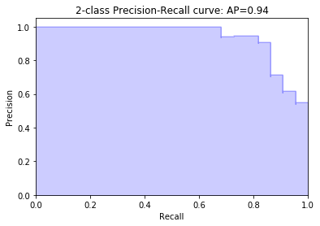

```python
precision, recall, thresholds = precision_recall_curve(y_test, y_pred) # get precision and recall curve values
average_precision = average_precision_score(y_test, y_pred) # get avg precision

step_kwargs = ({'step' : 'post'}) # step function kew arguments

plt.step(recall, precision, color='b', alpha=0.2,
         where='post')
plt.fill_between(recall, precision, alpha=0.2, color='b', **step_kwargs) # create step plot

plt.xlabel('Recall')
plt.ylabel('Precision')
plt.ylim([0.0, 1.05])
plt.xlim([0.0, 1.0])
plt.title('2-class Precision-Recall curve: AP={0:0.2f}'.format(average_precision))
```

**Analyze Results**

- For the most part, the model is not sensitive to changes in threshold since it is mostly uniform
- Additionally, our average precision (AP) is 0.94 which is almost 100% precise!

## Step 13: Pick an Optimal Threshold

Recall:

- Everything classified as a rock needs to be scanned at \$150/scan
- Everything classified as a mine needs to be defused at \$2000 if it is a real mine
- Everything classified as a mine needs to be defused at \$200 if it turns out to be a rock

```python
thresholds = [0.1,0.2,0.3,0.4,0.5,0.6,0.7,0.8,0.9] # different thresholds for tau

best_t = 0
best_cost = 10000000000 # arbitrarily large number
for t in thresholds:
    tn, fp, fn, tp = confusion_matrix(y_test,get_classification(y_pred,t)).ravel() # get confusion matrix values
    cost = (tn+fn) * 150 + 2000 * tp + 200 * fp # calculate cost
    print('*****')
    print('Threshold: {}'.format(t))
    print('Cost: {}'.format(cost))
    if cost < best_cost: # update best cost
        best_cost = cost
        best_t = t

print('\n\nSUMMARY')
print('Best threshold: {}'.format(best_t))
print('Best cost: {}'.format(best_cost))
```

```
*****
Threshold: 0.1
Cost: 49850
*****
Threshold: 0.2
Cost: 49650
*****
Threshold: 0.3
Cost: 49450
*****
Threshold: 0.4
Cost: 45450
*****
Threshold: 0.5
Cost: 43300
*****
Threshold: 0.6
Cost: 35600
*****
Threshold: 0.7
Cost: 30000
*****
Threshold: 0.8
Cost: 24450
*****
Threshold: 0.9
Cost: 17050


SUMMARY
Best threshold: 0.9
Best cost: 17050
```

We get the best outcome for this business case at a threshold of 0.9.

**Side-note:**

```python
X_train, X_test, y_train, y_test = train_test_split(X, y, test_size=0.25, random_state=42)
model = linear_model.LogisticRegression()
model.fit(X_train,y_train)
y_pred = model.predict_proba(X_test)[:,1] # to get probabilities of y = 1
acc = accuracy_score(y_true=y_test, y_pred=get_classification(y_pred,0.9))
acc
```

```
0.67307692307692313
```

Notice that the accuracy of this model is actually quite low! This shows that accuracy is not always the best method for assessing a model's success in the context of a business case, as true positives, false positives, true negatives, and false negatives each have an associated cost.

## Step 14: Summarize Client Deliverable

```python
import pandas as pd
import numpy as np
import matplotlib.pyplot as plt
from sklearn.model_selection import cross_validate
from sklearn.metrics import accuracy_score
from sklearn.preprocessing import LabelEncoder
from sklearn.datasets import make_classification
from sklearn.model_selection import KFold
from sklearn.model_selection import train_test_split
from sklearn import linear_model
from sklearn.metrics import roc_curve, auc
from sklearn.metrics import precision_recall_curve
from sklearn.metrics import average_precision_score
from sklearn.metrics import confusion_matrix
%matplotlib inline

def get_classification(predictions,threshold):
    classes = np.zeros_like(predictions)
    for i in range(len(classes)):
        if predictions[i] > threshold:
            classes[i] = 1
    return classes

url="http://archive.ics.uci.edu/ml/machine-learning-databases/undocumented/connectionist-bench/sonar/sonar.all-data"
df = pd.read_csv(url,header=None)

X = df[df.columns[0:60]].values
y = df[df.columns[60]].values

encoder = LabelEncoder()
encoder.fit(y)
y = encoder.transform(y)

X_train, X_test, y_train, y_test = train_test_split(X, y, test_size=0.25, random_state=42)
model = linear_model.LogisticRegression()
model.fit(X_train,y_train)
y_pred = model.predict_proba(X_test)[:,1] # to get probabilities of y = 1
get_classification(y_pred,0.9)
```

```
array([ 0.,  0.,  0.,  0.,  0.,  0.,  0.,  0.,  0.,  0.,  0.,  0.,  0.,
        0.,  0.,  0.,  0.,  0.,  0.,  0.,  0.,  0.,  0.,  0.,  0.,  0.,
        1.,  0.,  0.,  0.,  0.,  0.,  1.,  0.,  0.,  0.,  0.,  0.,  0.,
        0.,  1.,  0.,  0.,  0.,  1.,  0.,  0.,  0.,  0.,  1.,  0.,  0.])
```

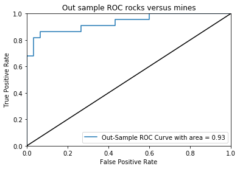

```python
(fpr, tpr, thresholds) = roc_curve(y_test,y_pred)

area = auc(fpr,tpr)
plt.clf() #Clear the current figure
plt.plot(fpr,tpr,label="Out-Sample ROC Curve with area = %1.2f"%area)

plt.plot([0, 1], [0, 1], 'k')
plt.xlim([0.0, 1.0])
plt.ylim([0.0, 1.0])
plt.xlabel('False Positive Rate')
plt.ylabel('True Positive Rate')
plt.title('Out sample ROC rocks versus mines')
plt.legend(loc="lower right")
plt.show()
```

```
Text(0.5,1,'2-class Precision-Recall curve: AP=0.94')
```

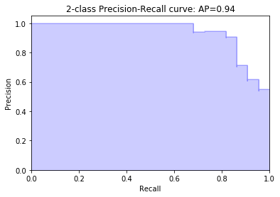

```python
precision, recall, thresholds = precision_recall_curve(y_test, y_pred)
average_precision = average_precision_score(y_test, y_pred)

step_kwargs = ({'step' : 'post'})

plt.step(recall, precision, color='b', alpha=0.2,
         where='post')
plt.fill_between(recall, precision, alpha=0.2, color='b', **step_kwargs)

plt.xlabel('Recall')
plt.ylabel('Precision')
plt.ylim([0.0, 1.05])
plt.xlim([0.0, 1.0])
plt.title('2-class Precision-Recall curve: AP={0:0.2f}'.format(average_precision))
```

The client now has a **cost-effective** model for detecting whether or not something is a rock or a mine based off of sonar readings. The above shows the predictions of the model.

## Conclusion

In this case, you learned:

- How to select and assess models
- How to turn a regression model into a classification model
- How to interpret ROC curves
- How to interpret Precision-Recall curves
- What it means to design a model under a business setting

It is always important to consider the business setting you are under. Here, what was "technically" the best model based on traditional data science metrics was not necessarily the best once we introduced business constraints. It is important to understand all business costs and benefits associated with your model.